# Telaffuz-YZ

Yapay Zekâ Tabanlı Türkçe Diksiyon ve Telaffuz Değerlendirme Sistemi

Onur Neşvat

İstanbul Üniversitesi-Cerrahpaşa — Yüksek Lisans Tezi

Haziran 2026

## Sunum Akışı

1. Problem ve motivasyon
2. Tanıma ile geri bildirim ayrımı
3. Sistem mimarisi
4. G2P katmanı
5. wav2vec2 eğitim kurulumu
6. wav2vec2 eğitim maliyeti ve PER
7. Fonem atlası
8. Atlas-GMM yöntemi
9. Runtime kontratı
10. Değerlendirme
11. Güvenlik–tespit dengesi
12. Demo, katkılar, gelecek çalışma

# 1 · Problem ve Motivasyon

## Türkçe için doğrulanmış bir CAPT hattı yok

- Bilgisayar destekli telaffuz öğretimi (**CAPT**) literatürü büyük ölçüde İngilizce ve yüksek kaynaklı diller üzerine olgunlaşmıştır (Witt ve Young 2000; Hu vd. 2015; Gong vd. 2022).
- Türkçe için boşluk yalnız veri seti eksikliği değildir; hedef IPA üretimi, IPA fonem tanıma ve kullanıcıya güvenli geri bildirim veren değerlendirme katmanı birlikte eksiktir.
- Mevcut Türkçe ASR sistemleri sözcük transkripti için optimize edilir; bu çalışma sesi metne değil, IPA fonem dizisine ve fonem-başına kalite/karar çıktısına taşır.

**Araştırma problemi:** Türkçe konuşma kayıtlarından fonetik doğruluk hakkında açıklanabilir ve kullanıcıya dönük geri bildirim üreten bir sistem nasıl tasarlanır?

## Türkçe fonolojisi dil-özgü karmaşıklık taşır

Türkçe yazı-sesletim ilişkisi düzenlidir; ancak **her zaman yazıldığı gibi okunan** bir dil değildir. Bazı harfler, çevresindeki seslere ve sözcük kökenine göre farklı ses değerleri alabilir.

| Olgu | Küçük örnek | Sistem için risk |
| --- | --- | --- |
| Yumuşak g | `dağ` → uzun ünlü; `değil` → [j]-benzeri geçiş | `ğ` tek bir sabit fonem değildir. |
| Açık /e/ | `ben`, `gel` gibi sonorant kodalı heceler | Kapalı/açık `e` ayrımı hedefte kaybolabilir. |
| Palatal / velar | `kal`–`kel`, `gel` | Ön ünlü çevresi /k, g/ yüzeyini değiştirir. |
| Uzun ünlüler | `hâlâ`, `kâr`, `adet`–`âdet` | Yazımdaki aksan/alıntı bilgisi süreyi etkiler. |

Genel amaçlı CAPT sistemlerinin doğrudan aktarımı bu olguları çözmez. Hedef, **yanlış yönlü geri bildirimden kaçınan** temkinli bir sistemdir.

# 2 · Tanıma ile Geri Bildirim Ayrımı

## ASR başka, telaffuz koçu başka soru sorar

| Katman | Dönüşüm | Çıktı | Ne işe yarar? |
| --- | --- | --- | --- |
| Genel ASR | ses -> metin | `"merhaba"` | Sözcük transkripti üretir; fonem üretim kalitesini ölçmez. |
| Bizim wav2vec-CTC | ses -> IPA fonem dizisi | `/m e ɾ h a b a/` | Gözlenen fonemleri çıkarır; PER bu kanalın tanıma doğruluğunu ölçer. |
| Telaffuz ölçücü | hedef IPA <-> gözlenen IPA + atlas | `status`, `quality`, `score` | Atlas tipiklikten `quality`, hedef-gözlem uzaklığından `score` üretir. |

Ana ayrım: **Metin transkripti değil, IPA düzeyinde hedef–gözlem karşılaştırması ve atlas temelli kalite kanıtı.**

# 3 · Sistem Mimarisi

## Dört bileşen, tek paylaşılan envanter

- Paylaşılan envanter: **49 hedef fonem**, **54 CTC birimi**, ortak IPA sözlüğü.
- Amaç: hedef metin, tanıyıcı çıktısı ve runtime değerlendirmesi aynı sembol uzayında kalsın.

| Hat | Bileşen | Üretilen kanıt |
| --- | --- | --- |
| Hedef hattı | Türkçe hedef metin -> G2P | Beklenen IPA dizisi |
| Tanıma hattı | Kullanıcı ses kaydı -> wav2vec2 CTC | Gözlenen fonem dizisi |
| Kanıt hattı | Fonem atlası -> runtime koç | `result.phones[]`: `status`, `score`, `quality`, `length` |

# 4 · G2P Katmanı

## Kural tabanlı grapheme-to-phoneme

Girdi Türkçe yazı biçimidir; çıktı 49 fonemlik IPA hedef dizisidir. Örnek:

`değil` -> `/deˈjil/`

| Aşama | İşlev | Örnek etki |
| --- | --- | --- |
| `normalize` | Unicode ve noktalama temizliği | `Hâlâ!` -> `hâlâ` |
| `exception_lookup` | Alıntı, özel ad ve uzun ünlü istisnaları | `kâr` -> uzun /aː/ |
| `morphology` | Kök, ek ve özel-ad bilgisini çıkarır | vurgu/ek kararları |
| `grapheme_map` | Temel harf -> IPA eşlemesi | `kedi` -> temel `/k e d i/` |
| Kurallar | Bağlama göre yüzey fonemleri üretir | `ğ`, palatalizasyon, açık /e/ |

Bilinmeyen sözcük sırası: istisna sözlüğü -> FSM morfoloji -> kural tabanlı dönüşüm -> karakter düzeyi geri çekilme.

## G2P işlem adımları ve örnekleri

| Sıra | Adım |
| --- | --- |
| 1 | `normalize` |
| 2 | `exception_lookup` |
| 3 | `morphology` |
| 4 | `grapheme_map` |
| 5 | `vowel_harmony` |
| 6 | `soft_g` |
| 7 | `palatalization` |
| 8 | `l_allophony` |
| 9 | `v_allophony` |
| 10 | `n_assimilation` |
| 11 | `e_open` |
| 12 | `aspiration` |
| 13 | `r_devoicing` |
| 14 | `stress` |
| 15 | `canonicalize_stress` |

| Kural | Girdi | IPA çıktısı |
| --- | --- | --- |
| Yumuşak g: coda uzatma | `dağ` | `/daː/` |
| Yumuşak g: ön ünlü glide | `değil` | `/deˈjil/` |
| Palatalizasyon | `kedi` | `/ˈcedi/` |
| Açık `/e/` | `ders` | `/dæɾs/` |
| Loan circumflex | `kâr` | `/caːɾ̞̊/` |
| Lateral allofoni | `kulak` | `/kuˈɫak/` |
| Yer adı stresi | `Ankara` | `/ˈankaɾa/` |

## G2P doğrulama kümeleri neyi ölçer?

| Küme | Ne demek? | Ne ölçer? | Sonuç |
| --- | --- | --- | --- |
| Blind-75 | 75 sözcüklük bağımsız uzman kör testi | Kural kapsamı + edge-case kontrolü | PER **0,015**, exact **%90,7** |
| MFA v3 | Montreal Forced Aligner Türkçe sözlüğü | 41.373 girdide geniş ölçekli segmental uyum | PER **0,032** |
| Wiktionary | Dış kaynak IPA girdileri | Gürültülü dış referansa dayanıklılık | PER **0,118** |

G2P çıktısı yalnız metin okuma değil; wav2vec eğitimi, hedef şablon üretimi ve runtime değerlendirmesi için ortak fonem hedefidir.

# 5 · wav2vec2 Eğitim Kurulumu

## Backbone’lar: aynı göreve iki ön-eğitim

| Backbone | Checkpoint | Kullanım |
| --- | --- | --- |
| MMS-1B | `facebook/mms-1b` | Varsayılan runtime modeli |
| XLS-R-300M | `facebook/wav2vec2-xls-r-300m` | Robustness karşılaştırması |

Karşılaştırma, farklı backbone’ların aynı Türkçe IPA-CTC görevinde nasıl davrandığını ölçer; hedef dağarcık ve veri bölmeleri ortaktır.

## Ortak CTC görevi

| Öğenin rolü | Değer |
| --- | --- |
| Girdi | 16 kHz konuşma segmenti |
| Hedef | G2P’den gelen IPA fonem dizisi |
| CTC dağarcığı | 54 token: 49 fonem + vurgu + `<spc>`, `<blank>`, `<pad>`, `<unk>` |
| Çıkış başlığı | Her frame için 54 token olasılığı |
| Çözümleme | CTC tekrar daraltma + özel token temizleme |

CTC kaybı, frame düzeyindeki olası yolları aynı hedef fonem dizisinde toplar:

$$\mathcal{L}_{CTC}
= -\log P(\mathbf{y}\mid\mathbf{x})
= -\log \sum_{\pi \in \mathcal{B}^{-1}(\mathbf{y})}
\prod_t p_t(\pi_t \mid \mathbf{x})$$

`<blank>` ve tekrar-daraltma mekanizması 54 tokenlık çıkış başlığının parçasıdır.

## Veri bölmesi ve eğitim protokolü

| Split | Segment | Saat | Rol |
| --- | --- | --- | --- |
| train | 239.555 | 275,48 | Optimizasyon |
| dev | 14.793 | 15,97 | Checkpoint seçimi |
| test | 15.277 | 18,65 | Held-out PER |

- Veri: **Common Voice 24.0 TR + ISSAI TSC**
- Filtre: **0,5-15 s** süre filtresi
- Ek koruma: cümle düzeyi deduplikasyon
- Eğitim: CNN feature encoder donduruldu
- Güncellenen katmanlar: transformer + lineer CTC başlığı
- Effective batch: **32**
- Learning rate: **1e-4**
- Bellek: FP16 + gradient checkpointing
- Model seçimi: minimum dev PER, seed 42

# 6 · wav2vec2 Eğitim Maliyeti ve PER

## Eğitim süresi

| Model | Step | Epoch | Yaklaşık GPU zamanı | Bitiş |
| --- | --- | --- | --- | --- |
| XLS-R-300M | 59.888 | 8 / 8 | **~20 saat** | Schedule tamamlandı |
| MMS-1B | 62.500 | 7,4 / 10 | **~37 saat** | En iyi checkpoint seçildi |
| Toplam | — | — | **~57 GPU-saat** | Tek RTX 3090 |

## Test-set PER sonuçları

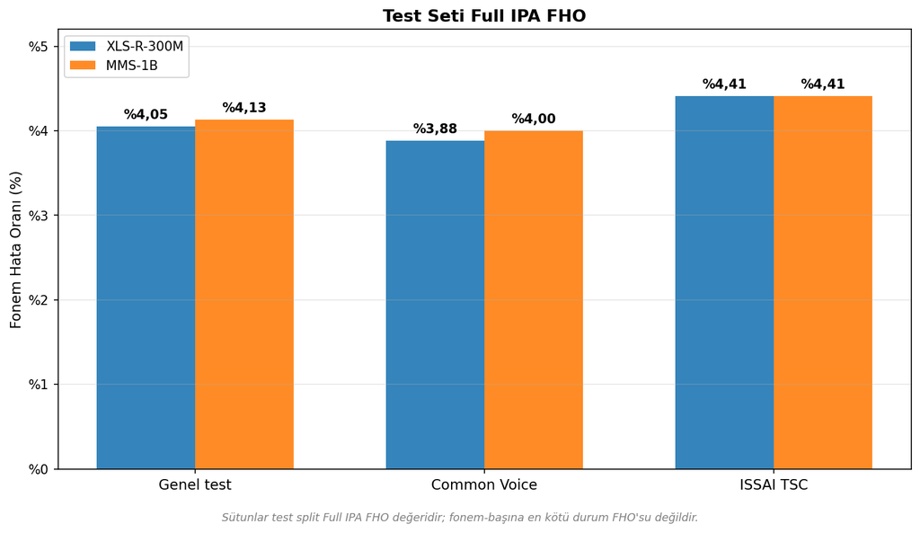

Test split Full IPA PER özeti

$$\mathrm{PER}_{Full\ IPA}
= \frac{S + D + I}{N_{ref}}
= \frac{\operatorname{Lev}(\hat{\mathbf{y}}, \mathbf{y})}{|\mathbf{y}|}$$

Burada $\mathbf{y}$ referans IPA fonem dizisi, $\hat{\mathbf{y}}$ CTC çıktısıdır; `S/D/I` ikame, silme ve ekleme editlerini gösterir. Test hesabında `<spc>` sözcük sınırı sayılmaz, vurgu işareti `ˈ` Full IPA metriğine dahildir.

# 7 · Fonem Atlası

## Büyük ölçekli akustik referans

- **544,72 saat** Türkçe konuşma
- **463.003** hizalanmış segment
- **22,4 milyon** fonem penceresi
- Kaynaklar:
  - Common Voice 24.0 TR
  - ISSAI TSC
  - kamu malı sesli kitaplar

**Atlasın sakladığı alanlar**

| Alan | Kullanım |
| --- | --- |
| `target_phone` | G2P kaynaklı hedef sınıf |
| `observed_phone` | wav2vec destekli analiz izi |
| `start_ms`, `end_ms` | fonem spanı ve aktif süre |
| formantlar | F1/F2/F3, özellikle ünlüler |
| spektral ipuçları | sürtünmeli, patlamalı, affrikat kanıtları |
| süre | uzun/kısa ünlü ve yerel hız |

Eksik akustik kanıt hata sayılmaz; `quality` veya `length` alanında yokluk olarak raporlanır.

## Akustik kanıt aileleri

| Kanıt | Ne ölçer? | Neden gerekli? |
| --- | --- | --- |
| **F1/F2/F3** | Ses yolunun rezonans tepeleri | F1 açıklık/yüksekliği, F2 ön-art konumu, F3 daha ince artikülasyon farklarını taşır. |
| **Ünlülerde F2 hareketi** | Hece içindeki F2 değişim hızı | Durağan formant değerinin kaçırdığı geçişleri ve yakın ünlü üretimlerini gösterir. |
| **Sürtünmeli ipuçları** | Spektral merkez, bant genişliği, gürültü enerjisi | `/s, ʃ, f, v/` gibi seslerde boğumlanma yerini ve sürtünme niteliğini ayırır. |
| **Patlamalı / affrikat ipuçları** | Patlama merkezi, VOT, kapanma-sonrası enerji | `/p, t, k/` ve `/t͡ʃ, d͡ʒ/` ayrımlarında kısa süreli ipuçlarını yakalar. |
| **Süre kanalı** | Fonem süresi ve yerel konuşma hızına göre sapma | Uzun/kısa ünlü farkını karar kapısı yapmadan açıklayıcı kanıt olarak taşır. |

Bu kanıtlar kullanıcıya dönük `status` kararını tek başına değiştirmez; atlas/GMM kalite ve süre kanallarını besler.

# 8 · Atlas-GMM Yöntemi

## Fonem-başına GMM

Her fonem için aday özellikler sınıfa göre seçilir; kapsama oranı yeterli olmayan özellikler düşer. Kalan vektör:

$$x_p = [f_1, f_2, \ldots, f_d]$$

Fonem yoğunluğu en fazla 3 bileşenli full-covariance GMM ile modellenir:

$$p_p(x)=\sum_{k=1}^{K_p} w_{pk}\,\mathcal{N}(x;\mu_{pk},\Sigma_{pk})$$

Okuma anahtarı: `p` fonem kimliği, `x_p` o fonem için ölçülen özellik vektörü, `d` özellik sayısı, `K_p` bileşen sayısı, `w_pk` bileşen ağırlığı, `mu_pk` ve `Sigma_pk` bileşen ortalaması ve kovaryansıdır. Amaç, üretimin hedef fonemin atlas dağılımında ne kadar tipik olduğunu ölçmektir.

## Model seçimi ve kalite kalibrasyonu

**GMM eğitimi**

- `K <= 3`
- full covariance
- `reg_covar = 1e-3`
- bileşen başına en az 30 örnek
- K seçimi: minimum BIC

$$\mathrm{BIC}_K = m_K \log n - 2\log \hat L_K$$

**Runtime kalite skoru**

GMM log-density, fonem içi native quantile grid ile ortak ölçeğe taşınır:

$$q_p(x)=\frac{\operatorname{rank}_{Q_p}(\log p_p(x))}{|Q_p|}$$

Süre kanalı:

$$z_p=\frac{d_{ms}-\mathrm{median}_p}{\mathrm{scale}_p}$$

`quality` ve `length` açıklayıcı kanallardır; hizalanmış `status` kararını doğrudan değiştirmez.

# 9 · Runtime Kontratı

## Dört çıktı yüzeyi ayrı tutulur

**status**

`correct` `incorrect` `missing` `extra`

**score**

fonetik mesafe

**quality**

GMM tipiklik

**length**

süre kanalı

- `result.phones[]`, hedef diziyi analiz edilen gözlemle hizalar.
- `incorrect` ve `missing`, validation metriklerinde flagged hedef statüleridir.
- `extra`, hedef fonem yanlış-pozitifi sayılmaz; sözcük skoruna ayrı ceza olarak yansır.

## Skor formülü

Fonem skoru beklenen ve gözlenen telefon arasındaki fonetik uzaklığa dayanır:

- birebir eşleşme tam kredi alır;
- yakın fonetik komşular kısmi kredi alabilir;
- `missing` sıfır skor üretir;
- `extra` hedef ortalamasına girmez, `extra_penalty` ile sözcük skorunu düşürür.

$$\text{overall} = 100 \times \overline{\text{phone\_score}} \times \text{extra\_penalty}$$

# 10 · Değerlendirme

## Doğrulama tasarımı

- **2 anadili konuşmacı** (K1, K2)
- **150 kayıt**
- **2.324 hedef fonem**
- Üç koşul:
  - **CTL** — kontrol doğru okuma
  - **W_NAT** — doğal doğru hedef sözcük
  - **W_ERR** — kasıtlı hata konumları

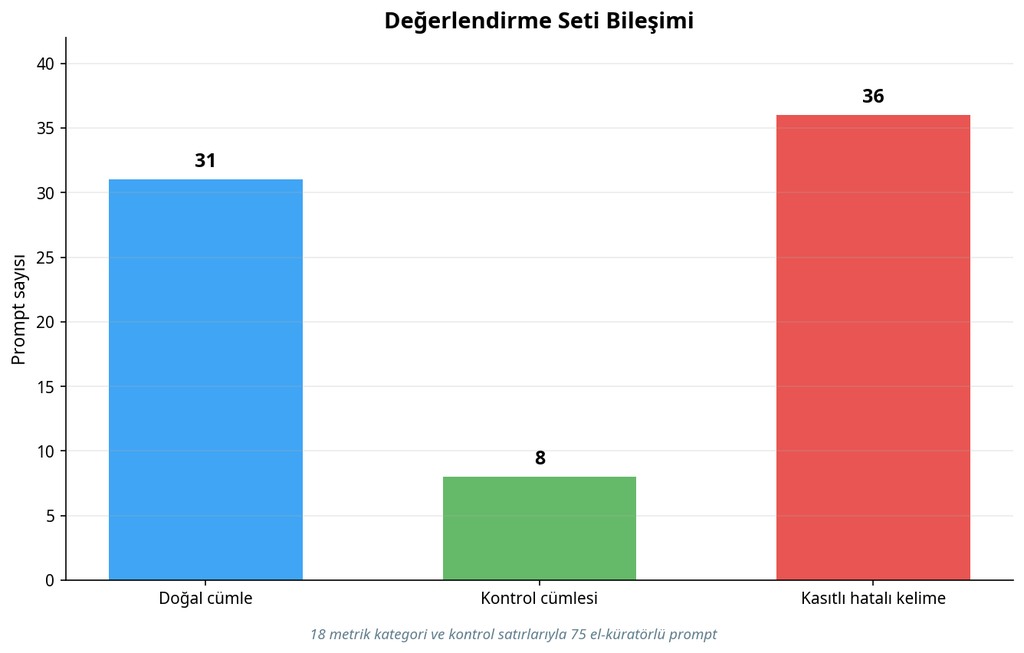

Değerlendirme seti bileşimi

Metrikler tasarım doğrulamasıdır; gerçek L2 öğrenici davranışına doğrudan genellenmez.

## Baseline sonuçlar

| Grup | Fonem | correct | incorrect | missing | extra | Ana metrik |
| --- | --- | --- | --- | --- | --- | --- |
| CTL | 454 | 430 | 18 | 6 | 1 | FP **%5,29** |
| W_NAT | 1.498 | 1.415 | 63 | 20 | 10 | FP **%5,54** |
| W_ERR | 372 | 294 | 73 | 5 | 23 | detection **%65,62** |

- W_ERR precision@error: **%53,85**.
- Ortalama fonem skoru: CTL **0,968**, W_NAT **0,969**, W_ERR **0,916**.
- Doğal doğru konuşmada FP’ler kalır; kasıtlı hata konumlarının yaklaşık üçte ikisi yakalanır.

## Backbone robustness

| Backbone | Rol | CTL FP | W_NAT FP | Detection | Precision@err |
| --- | --- | --- | --- | --- | --- |
| MMS-1B | varsayılan | %5,29 | %5,54 | %65,62 | %53,85 |
| XLS-R-300M | robustness | %5,07 | %5,81 | %65,62 | %56,00 |

Backbone değişince tespit aynı kalır; FP profili aynı banddadır. Sorun yalnız checkpoint seçimi değildir.

# 11 · Güvenlik–Tespit Dengesi

## Neden farklı çalışma noktaları?

Bu bölüm yeni model eğitimi değildir; **aynı 150 kayıt** aynı G2P, wav2vec ve atlas çıktılarıyla yeniden yorumlanır.

| Soru | Ölçülen karşılık |
| --- | --- |
| Daha az yanlış geri bildirim verebilir miyiz? | CTL ve W_NAT yanlış-pozitif oranı |
| Bunun tespit maliyeti nedir? | W_ERR tasarlanmış hata konumu tespiti |
| İşaretlenen hatalar hedeflenen konumda mı? | Precision@err |

Amaç, kullanıcıya hata mesajı verirken çalışma noktasını nerede seçeceğimizi görmek: **tespit öncelikli mi, güvenlik öncelikli mi?**

## Politikalar neyi yumuşatır?

| Politika | Ne değişir? | Beklenen etki |
| --- | --- | --- |
| Varsayılan | Her `incorrect` veya `missing` hedef fonem işaretlenir. | En yüksek tespit, daha fazla FP |
| Allofonları yumuşat | Aynı fonemin yüzey varyantları hata sayılmaz. | Küçük FP azalması, tespit düşer |
| Yalnız ünlüler | Yalnız non-allofonik ünlü ikameleri işaretlenir. | Ünsüz FP’leri azalır, ünsüz hatalar kaçar |
| Missing yok | `missing` hedefler hata mesajına çevrilmez. | FP çok düşer, zayıf/eksik üretimler kaçabilir |
| Ünlü veya uzak ünsüz | Ünlülere ek olarak skoru çok düşük ünsüzler işaretlenir. | Bazı ünsüz hataları geri gelir, FP biraz artar |

Bu politikalar model çıktısını değiştirmez; yalnız `incorrect`/`missing` satırlarının kullanıcıya hata olarak gösterilip gösterilmeyeceğini değiştirir.

## Aynı kayıtlar, farklı çalışma noktaları

| Politika | CTL FP | W_NAT FP | Tespit | Precision@err |
| --- | --- | --- | --- | --- |
| Varsayılan baseline | **%5,29** | **%5,54** | **%65,62** | **%53,85** |
| Allofonları yumuşat | %4,41 | %4,67 | %51,56 | %50,77 |
| Yalnız ünlü kontrastı | %1,54 | %2,14 | %29,69 | %59,38 |
| Ünlü + missing yumuşat | **%0,22** | **%0,80** | %29,69 | **%70,37** |
| Ünlü veya uzak ünsüz | %2,20 | %2,54 | %32,81 | %50,00 |
| Ünlü/uzak ünsüz + missing yok | %0,88 | %1,20 | %32,81 | %56,76 |

FP azaltılabilir; fakat aynı kayıtlar üzerinde tespit oranı ciddi biçimde düşer.

## Frontier görselleştirmesi

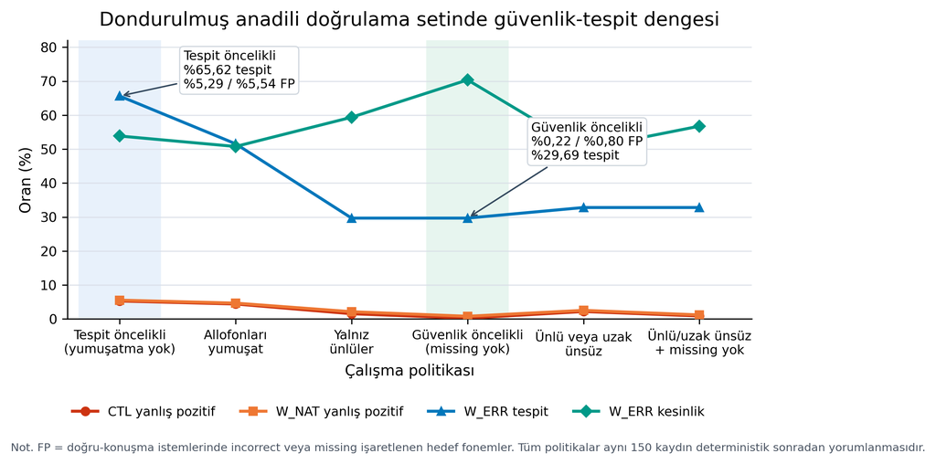

Güvenlik-tespit dengesi

Turuncu/kırmızı çizgiler doğal-doğru kayıtların yanlış-pozitif oranını; mavi çizgi W_ERR tespitini; yeşil çizgi işaretlenen hataların hedeflenen hata konumuna düşme oranını gösterir.

## Sonuçların anlamı

**Tespit öncelikli okuma**

- Varsayılan politika W_ERR hatalarının **%65,62**’sini yakalar.
- Bedeli: doğal doğru konuşmada yaklaşık **%5** hedef fonem işaretlenir.
- Bu ayar analiz ve prototip doğrulama için yararlıdır.

**Güvenlik öncelikli okuma**

- `missing` yumuşatması FP’yi **%0,22 / %0,80** bandına indirir.
- Bedeli: tespit yaklaşık **%29,69** düzeyine iner.
- Bu ayar kullanıcıya az ama daha temkinli geri bildirim vermek için uygundur.

Ana bulgu: PER düşük olsa bile, geri bildirim güvenliği ayrı ölçülmelidir; çünkü yanlış-pozitifler ve gerçek hatalar tek bir skor eşiğiyle temiz ayrışmaz.

# 12 · Demo, Sonuç ve Gelecek

## Çalışan prototip

- **FastAPI** servis: sağlık kontrolü, fonem envanteri, G2P inceleme, model listesi ve `POST /api/v1/assess`.
- **React + TypeScript** push-to-talk arayüz: G2P çıktısı, kural izi, hizalama şeridi, fonem-başına status/score ve Türkçe geri bildirim.
- Yöntem yalnızca deney sonuçlarıyla değil, uçtan uca çalışan bir prototiple gösterilir.

## Sonuç: tanıma değil, temkinli feedback hattı

| Katman | Gösterilen sonuç |
| --- | --- |
| G2P hedef üretimi | Blind-75 PER **0,015**, exact **%90,7** |
| Fonem tanıma | Test Full IPA PER: XLS-R **%4,05**, MMS-1B **%4,13** |
| Runtime değerlendirme | Doğal doğru konuşmada hedeflerin yaklaşık **%94-95**’i `correct` kalır |
| Hata yakalama | W_ERR tasarlanmış hata konumlarında detection **%65,62** |
| Güvenlik sınırı | FP <%1 yapılabilir; ancak tespit yaklaşık **%30** bandına iner |

Ana sonuç: Türkçe için fonem düzeyinde çalışan uçtan uca hat kurulmuştur; fakat **tanıma başarısı**, kullanıcıya verilecek geri bildirimin güvenliğiyle aynı metrik değildir.

## Katkılar

1. 49 fonemlik Türkçe IPA envanteri + 15 adımlı G2P.
2. Ortak 54 CTC birimiyle iki backbone karşılaştırması.
3. 544,72 saatlik atlas ve fonem-başına GMM kalite kanalı.
4. `status/score/quality/length` üreten runtime kontratı.
5. Aynı kayıtlar üzerinde safety-detection frontier.

## Sınırlılıklar ve gelecek çalışma

- W_ERR kontrollü hata senaryosudur; gerçek L2 popülasyonuna doğrudan genellenmez.
- Türkçe için çok-puanlayıcılı L2 doğrulama seti gerekir (Zhao vd. 2018; Zhang vd. 2021).
- Cross-model uzlaşması, atlas destekli çekimserlik ve L1’e özgü hata profilleri sıradaki eksendir.

## Teşekkürler

**Telaffuz-YZ:** Türkçe için açıklanabilir, fonem düzeyinde çalışan ve geri bildirim güvenliğini ayrı ölçen telaffuz değerlendirme sistemi.

Sorular ve tartışma için teşekkürler.

## Kaynakça

Gong, Yuan, Ziyi Chen, Iek-Heng Chu, Peng Chang, ve James Glass. 2022. “Transformer-Based Multi-Aspect Multi-Granularity Non-Native English Speaker Pronunciation Assessment”. *ICASSP 2022 – 2022 IEEE International Conference on Acoustics, Speech and Signal Processing* (Singapore), 7262-66. https://doi.org/10.1109/ICASSP43922.2022.9746743.

Hu, Wei, Yao Qian, Frank K. Soong, ve Yue Wang. 2015. “Improved Mispronunciation Detection with DNN Trained Acoustic Models and Transfer Learning Based Score Normalization”. *Speech Communication* 67: 154-66. https://doi.org/10.1016/j.specom.2014.11.003.

Witt, Silke M., ve Steve J. Young. 2000. “Phone-Level Pronunciation Scoring and Assessment for Interactive Language Learning”. *Speech Communication* 30 (2–3): 95-108. https://doi.org/10.1016/S0167-6393(99)00073-5.

Zhang, Junbo, Yongqing Zou, Kun Zhou, Chu Yuan Huang, Michael X. Q. Zhao, ve Duc T. Li. 2021. “speechocean762: An Open-Source Non-Native English Speech Corpus for Pronunciation Assessment”. *Interspeech 2021*, 3048-52. https://doi.org/10.21437/Interspeech.2021-1905.

Zhao, Guanlong, Sinem Sonsaat, Alif Silpachai, vd. 2018. “L2-ARCTIC: A Non-native English Speech Corpus”. *Interspeech 2018*, 2783-87. https://doi.org/10.21437/Interspeech.2018-1110.